# Data Visualization and Analysis of Backstreet Boys Song Lyrics

Tong Dai

9/12/2019

[figure not shown]

[output not shown]

#### Our goal is to first perform exploratory analysis and then move to text mining including sentiment analysis which involves Natural Language Processing.

#### Exploratory analysis

- word counts based on tracks and albums
- time series analysis of word counts
- distribution of word counts

#### Text mining

- word cloud
- topic modeling
- sentiment analysis (includes chord diagram)

#### About datasets:

- “lyrics.csv” is a filtered corpus of 380,000+ song lyrics from from MetroLyrics. You can read more about it on [Kaggle](https://www.kaggle.com/gyani95/380000-lyrics-from-metrolyrics).
- “artists.csv” provides the background information of all the artistis. These information are scraped from [LyricsFreak](https://www.lyricsfreak.com/).

Let’s first find out the top 10 songs with the most number of words. The code snippet given below includes the packages required in this analysis and finds out the top songs in terms of length.

This report is prepared with the following environmental settings.

```r
print(R.version)
```

```
##                _
## platform       x86_64-apple-darwin15.6.0
## arch           x86_64
## os             darwin15.6.0
## system         x86_64, darwin15.6.0
## status
## major          3
## minor          5.3
## year           2019
## month          03
## day            11
## svn rev        76217
## language       R
## version.string R version 3.5.3 (2019-03-11)
## nickname       Great Truth
```

Step 1 - Load the processed text data along with artist csv dataset

```r
# We use the processed data for our analysis
load('../output/processed_lyrics.RData')
# load artist information
dt_artist <- read_csv('../data/artists.csv')

# Pick preferred artist from Artist dataset and lookup dataset from lyrics dataset
# We select a subset of the data that satisfies analysis objective.
lyrics <- dt_lyrics[dt_lyrics$artist == "backstreet-boys",]
```

#### Exploratory analysis

Question 1: BSB is such a classic and old boy band, what’s the secret for their success and gained such large fans base worldwide, is it because of how they wrote songs or because of their physical appearance?

For me, I love BSB because their songs are so touching and emotion. With reasonable lyrics words, plus their emotion express inside the song have provided a different kind of listening experience compare to other well-known artist.

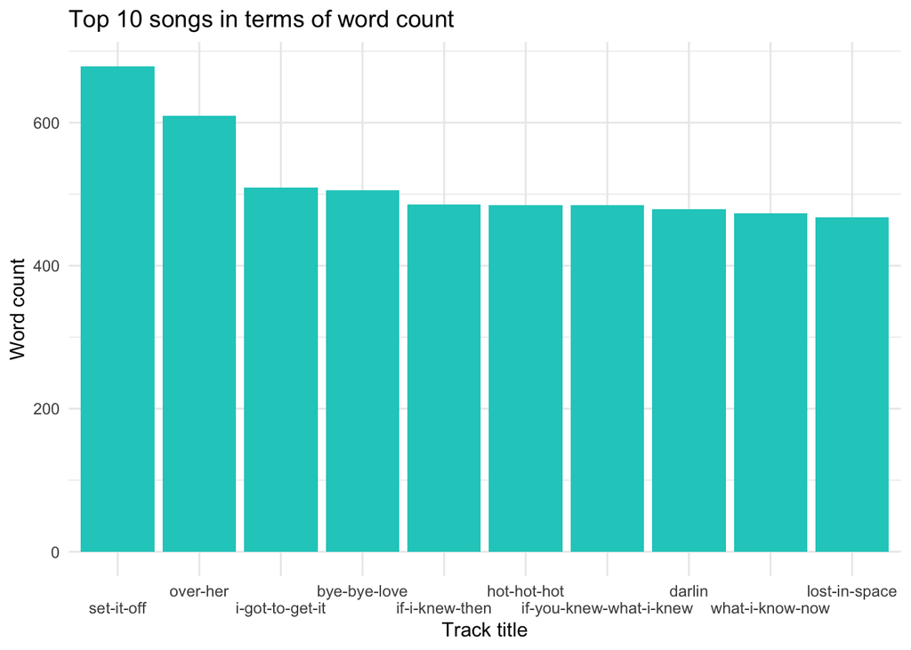

```r
# check how many charters for each lyrics text
lyrics$length <- str_count(lyrics$lyrics,"\\S+")

# generate summary of number of song with its revelent words in each song
length_df <- lyrics %>%
             group_by(song) %>%
             summarise(length = sum(length))

# visualize top
length_df %>%
  arrange(desc(length)) %>%
  slice(1:10) %>%
  ggplot(., aes(x= reorder(song, -length), y=length)) +
  geom_bar(stat='identity', fill="#1CCCC6") +
  ylab("Word count") + xlab ("Track title") +
  ggtitle("Top 10 songs in terms of word count") +
  theme_minimal() +
  scale_x_discrete(labels = function(labels) {
    sapply(seq_along(labels), function(i) paste0(ifelse(i %% 2 == 0, '', '\n'), labels[i]))
  })
```

```r
lyrics[lyrics$song == "set-it-off",c(1,2,3)]
```

```
## # A tibble: 1 x 3
##   song        year artist
##   <chr>      <dbl> <chr>
## 1 set-it-off  2007 backstreet-boys
```

Here are the Top 10 songs in terms of work count, and We can see that `set it off` (released in their 2007 album) is the song with maximum number of words and next in line is “over her” and rest are pretty much having equal number of words, can possible explain why people love their songs, familiarity and relationship bound. People tend to stay with what they are familiar and what they love.

Now, how about the songs with the lowest number of words? Let’s find out using the following code:

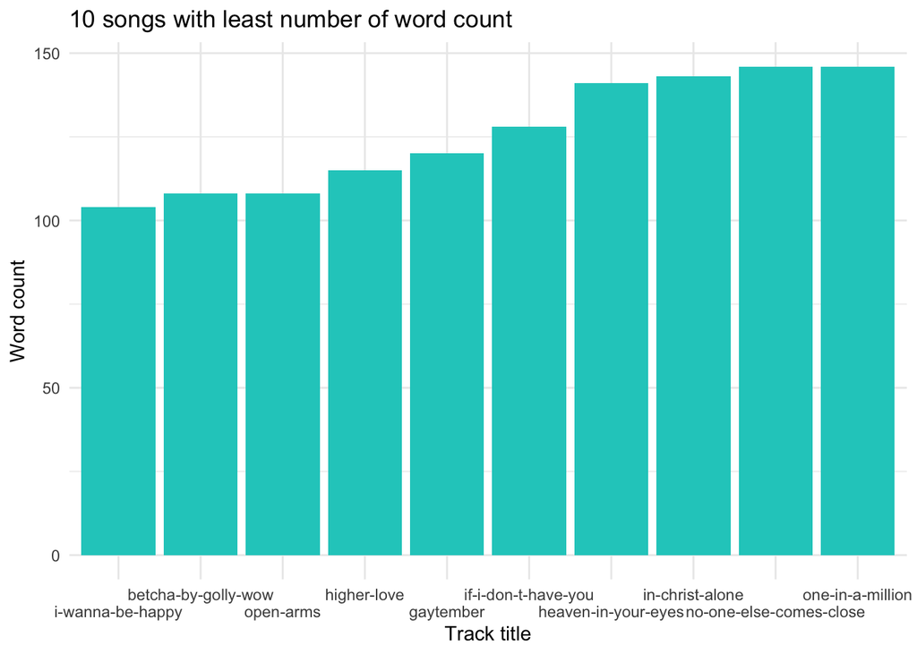

```r
length_df %>%
  arrange(length) %>%
  slice(1:10) %>%
  ggplot(., aes(x= reorder(song, length), y=length)) +
  geom_bar(stat='identity', fill="#1CCCC6") +
  ylab("Word count") + xlab ("Track title") +
  ggtitle("10 songs with least number of word count") +
  theme_minimal() +
  scale_x_discrete(labels = function(labels) {
    sapply(seq_along(labels), function(i) paste0(ifelse(i %% 2 == 0, '', '\n'), labels[i]))
  })
```

```r
lyrics[lyrics$song == "betcha-by-golly-wow",c(1,2,3)]
```

```
## # A tibble: 1 x 3
##   song                 year artist
##   <chr>               <dbl> <chr>
## 1 betcha-by-golly-wow  2006 backstreet-boys
```

The next analysis is centered around the distribution of the number of words.

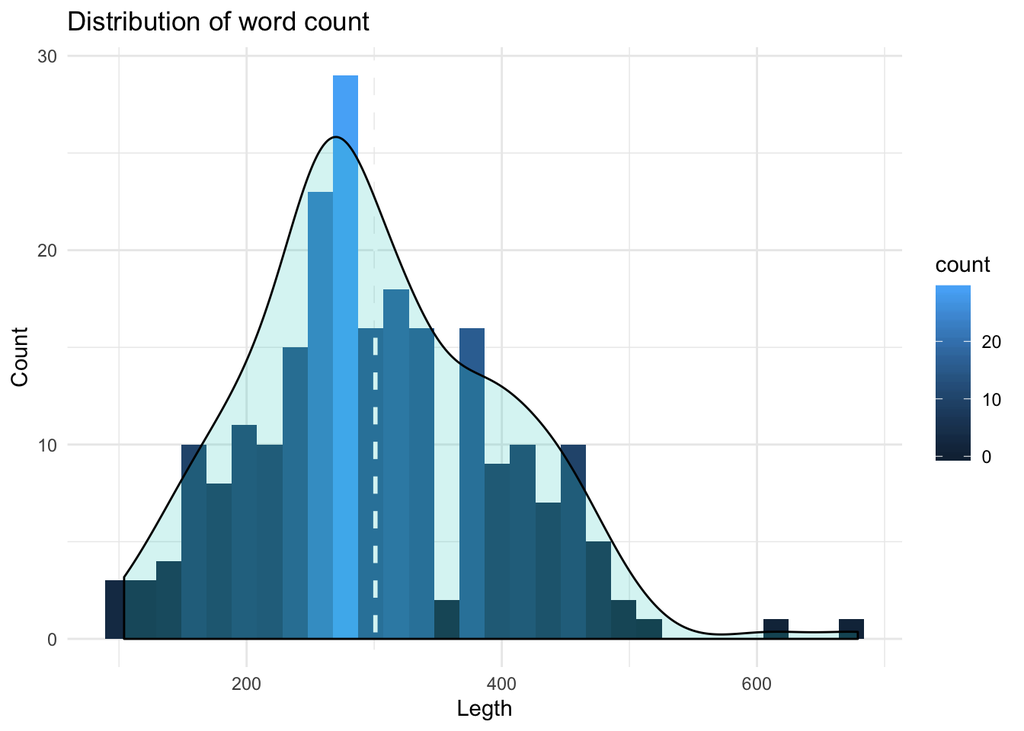

```r
ggplot(length_df, aes(x=length)) +
  geom_histogram(bins=30,aes(fill = ..count..)) +
  geom_vline(aes(xintercept=mean(length)),
             color="#FFFFFF", linetype="dashed", size=1) +
  geom_density(aes(y=25 * ..count..),alpha=.2, fill="#1CCCC6") +
  ylab("Count") + xlab ("Legth") +
  ggtitle("Distribution of word count") +
  theme_minimal()
```

The average word count for the song stands close to 300, and chart shows that maximum number of songs fall in between 250 to 330 words.

```r
# load subset of dataset for Pop artisist for benchmark
pop_lyrics <- dt_lyrics[dt_lyrics$genre == "Pop",]

# all artist words distribution
pop_lyrics$length <- str_count(pop_lyrics$lyrics,"\\S+")

all_pop_artist_words_length <- pop_lyrics %>%
             group_by(artist) %>%
             summarise(length = average_mean(length))

# within all pop artists, the average words count for all their songs
all_pop_artist_words_length %>% summarise(pop_length = average_mean(length))
```

```
## # A tibble: 1 x 1
##   pop_length
##        <dbl>
## 1       248.
```

Now, we’ll move to the analysis based on year.

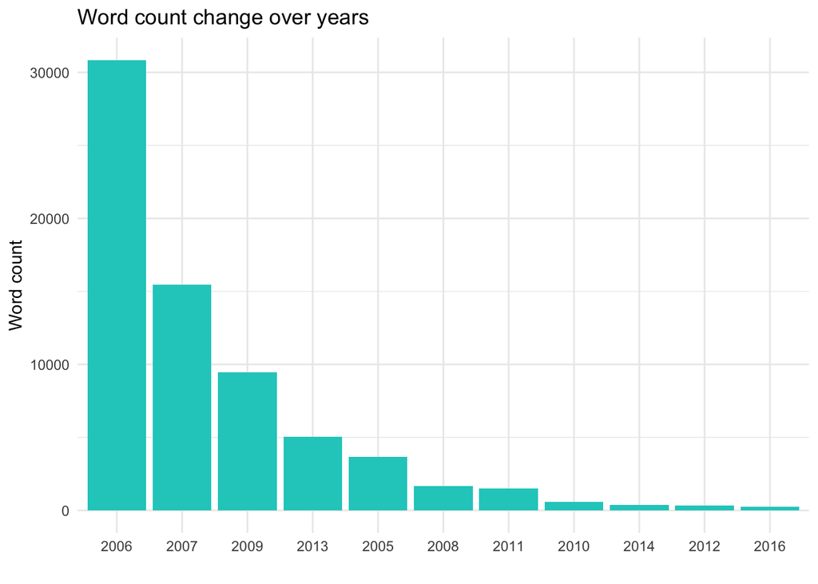

```r
# We first create a data frame with word counts based on year of release.
lyrics %>%
group_by(year) %>%
summarise(length = sum(length)) -> length_df_year

# Then we create a chart that will depict the year based on cumulative word count of the songs.
length_df_year %>%
arrange(desc(year)) %>%
ggplot(aes(x= reorder(year, -length), y=length)) +
geom_bar(stat='identity', fill="#1CCCC6") +
ylab("Word count") + xlab ("") +
ggtitle("Word count change over years") +
theme_minimal()
```

But, is that because of the number of words in individual song? Let’s find out:

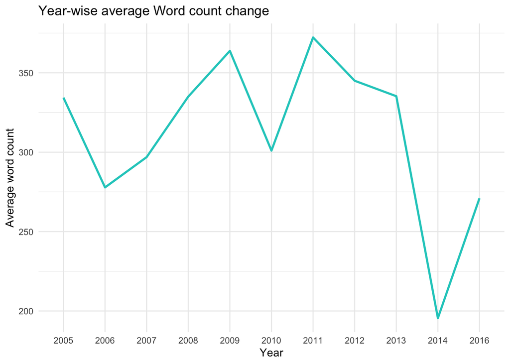

```r
#adding year column by matching song
length_df$year <- lyrics$year[match(length_df$song, lyrics$song)]

length_df %>%
 group_by(year) %>%
 summarise(length = mean(length)) %>%
   ggplot(., aes(x= factor(year), y=length, group = 1)) +
   geom_line(colour="#1CCCC6", size=1) +
   ylab("Average word count") + xlab ("Year") +
   ggtitle("Year-wise average Word count change") +
   theme_minimal()
```

The chart confirms that the average word count was increased for few years, then decreased significantly since 2011 (from 275 in 2006 to 375 in 2011, then from 380 to 200 words in 2014), i.e., this drop likely due to aging from the group memebers and focus more time on family and tours rather than writing new songs.

#### Text mining

Question 2: Can Backstreet boys’ song warm your heat during winter, downtime, or when someone is depressed. Any indicator to give people hope remind them what is love feeling like?

First, I would be to create a word cloud so that we can visualize the frequently of used words in their lyrics.

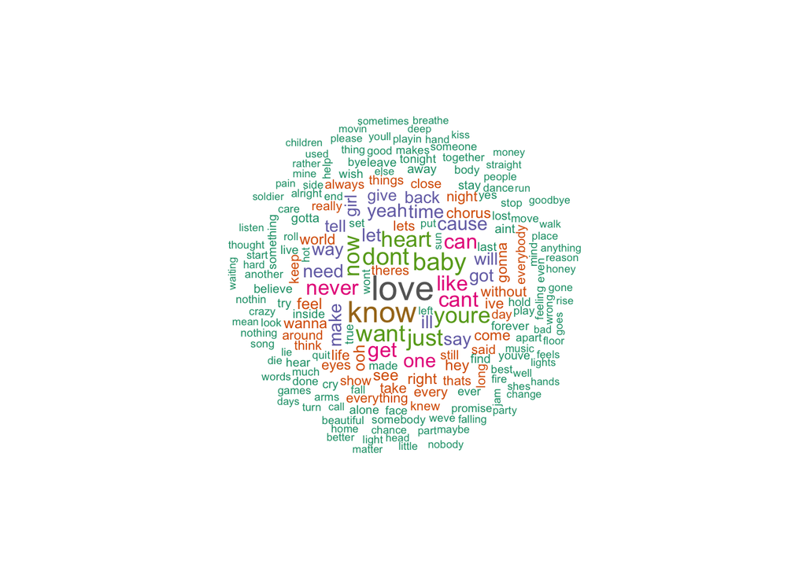

```r
#prepare to analysis text
lyrics_text <- lyrics$lyrics

#Removing punctations and alphanumeric content
lyrics_text<- gsub('[[:punct:]]+', '', lyrics_text)
lyrics_text<- gsub("([[:alpha:]])\1+", "", lyrics_text)

#creating a text corpus
docs <- Corpus(VectorSource(lyrics_text))

# Converting the text to lower case
docs <- tm_map(docs, content_transformer(tolower))

# Removing english common stopwords
docs <- tm_map(docs, removeWords, stopwords("english"))

# creating term document matrix
tdm <- TermDocumentMatrix(docs)

# defining tdm as matrix
m <- as.matrix(tdm)

# getting word counts in decreasing order
word_freqs = sort(rowSums(m), decreasing=TRUE)

# creating a data frame with words and their frequencies
lyrics_wc_df <- data.frame(word=names(word_freqs), freq=word_freqs)

lyrics_wc_df <- lyrics_wc_df[1:300,]

# plotting wordcloud
set.seed(1234)
wordcloud(words = lyrics_wc_df$word, freq = lyrics_wc_df$freq,
min.freq = 1,scale=c(1.8,.5),
max.words=200, random.order=FALSE, rot.per=0.15,
colors=brewer.pal(8, "Dark2"))
```

The word cloud shows that the most frequently used words like: `love`, `know`, `like`, `don't`, `you're`, `want`, `baby`, `now`, `yeah`, `can't`, `heart`, `never`. This confirms that their songs are predominantly about someone as you’re has significant number of occurrences.

#### Sentiment analysis

Question 3: BSB is indeed populate group in the world, but how many people really know them. Can we find out some insights about their personality and life experience from their songs?

We’ll first find out the overall sentiment via `nrc` method of `syuzhet` package. Below code will generate the chart of positive and negative polarity along with associated emotions.

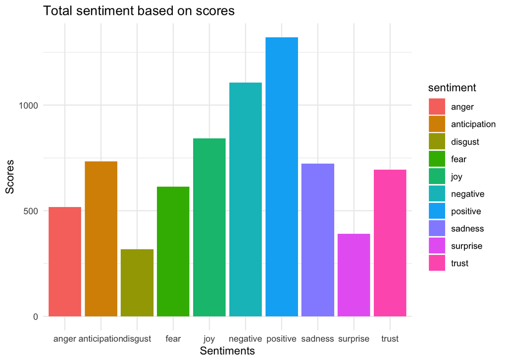

```r
# Getting the sentiment value for the lyrics
ty_sentiment <- get_nrc_sentiment((lyrics_text))

# Dataframe with cumulative value of the sentiments
sentimentscores<-data.frame(colSums(ty_sentiment[,]))

# Dataframe with sentiment and score as columns
names(sentimentscores) <- "Score"
sentimentscores <- cbind("sentiment"=rownames(sentimentscores),sentimentscores)
rownames(sentimentscores) <- NULL

# Plot for the cumulative sentiments
ggplot(data=sentimentscores,aes(x=sentiment,y=Score))+
geom_bar(aes(fill=sentiment),stat = "identity")+
theme(legend.position="none")+
xlab("Sentiments")+ylab("Scores")+
ggtitle("Total sentiment based on scores")+
theme_minimal()
```

The chart shows that the positive and negative sentiment scores are relatively close with 1300 and 1100 value respectively, but positive segment is slightly higher. Coming to the emotions, `joy`, `anticipation` and `sadness` emerge as the top 3.

Now that we have figured out the overall sentiment scores, we should find out the top words that contribute to various emotions and positive/negative sentiment.

```r
# data Processing --- prepare for sentiment
lyrics$lyrics <- as.character(lyrics$lyrics)

tidy_lyrics <- lyrics %>%
unnest_tokens(word,lyrics)

song_wrd_count <- tidy_lyrics %>% count(song)

lyric_counts <- tidy_lyrics %>%
left_join(song_wrd_count, by = "song") %>%
rename(total_words=n)
```

Using the `Bing` Lexicon we can categorize all words in the tweets as being positive or negative.

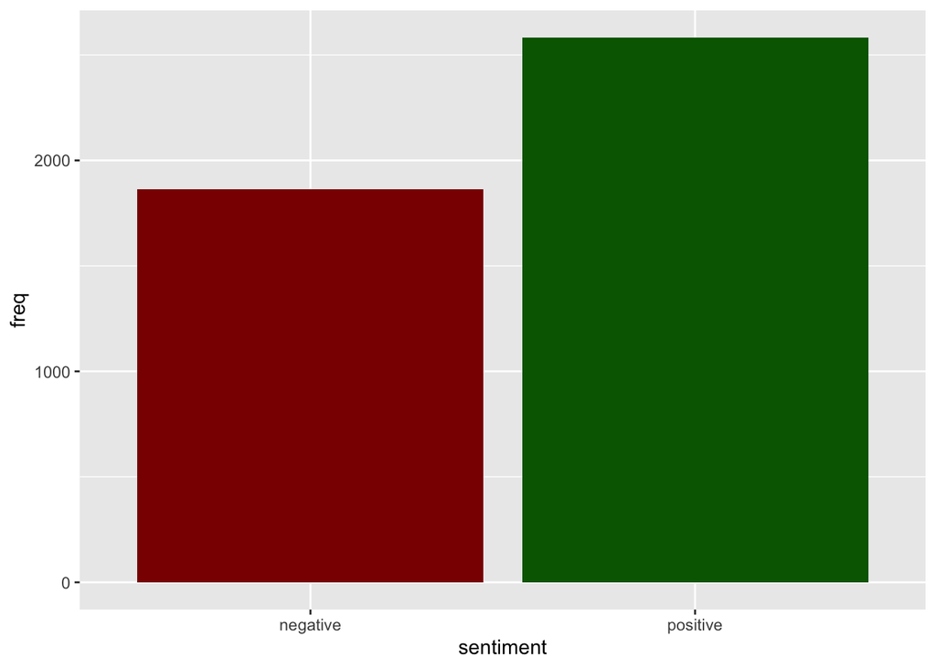

```r
# Using the Bing Lexicon we can categorize all words in the tweets as being positive or negative.
lyric_counts %>%
  inner_join(get_sentiments('bing'),by = 'word')%>%
  select('sentiment')%>%
  group_by(sentiment)%>%
  summarize(freq=n())%>%
  ungroup()%>%
  ggplot(aes(x=sentiment,y=freq))+geom_bar(position='dodge',stat='identity',fill=c('darkred','darkgreen'))
```

This charts shows most words they used inside the songs are more toward positive emotion.

Another popular Lexicon is afinn. This lexicon of words assigns scores words on the extent to which they are positive or negative.

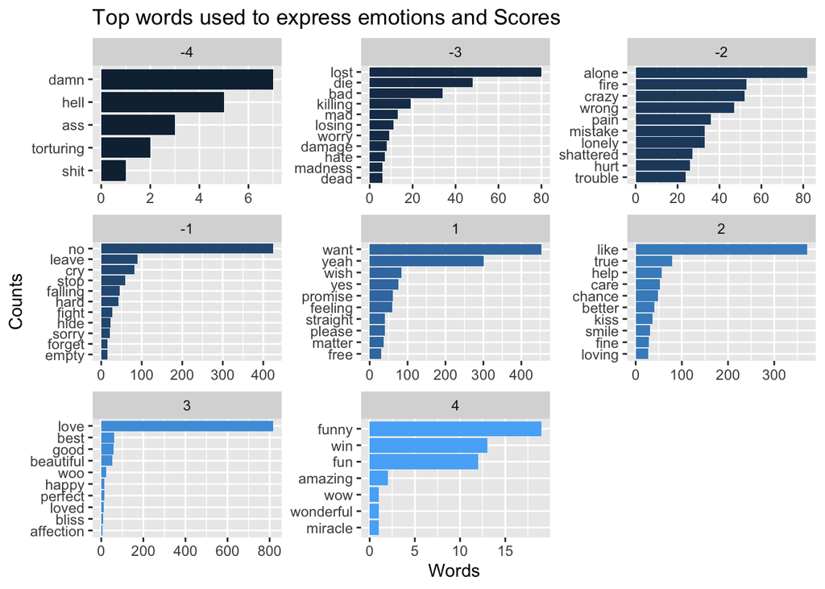

```r
lyric_value <- lyric_counts %>%
inner_join(get_sentiments("afinn"),by="word")

lyric_value %>%
count(word,value,sort=TRUE) %>%
group_by(value)%>%top_n(n=10) %>%
ungroup() %>%
ggplot(aes(x=reorder(word,n),y=n,fill=value)) +
geom_col(show.legend = FALSE) +
facet_wrap(~value,scales="free") +
xlab("Counts") + ylab("Words")+
ggtitle("Top words used to express emotions and Scores") +
coord_flip()
```

By applying the afinn lexicon to the words in the tweets, we can compute a score for each words. By averaging the scores of all words, one can obtain an overall sentiment score.

Use loughran lxicon to see top words used to express emotions and sentiments

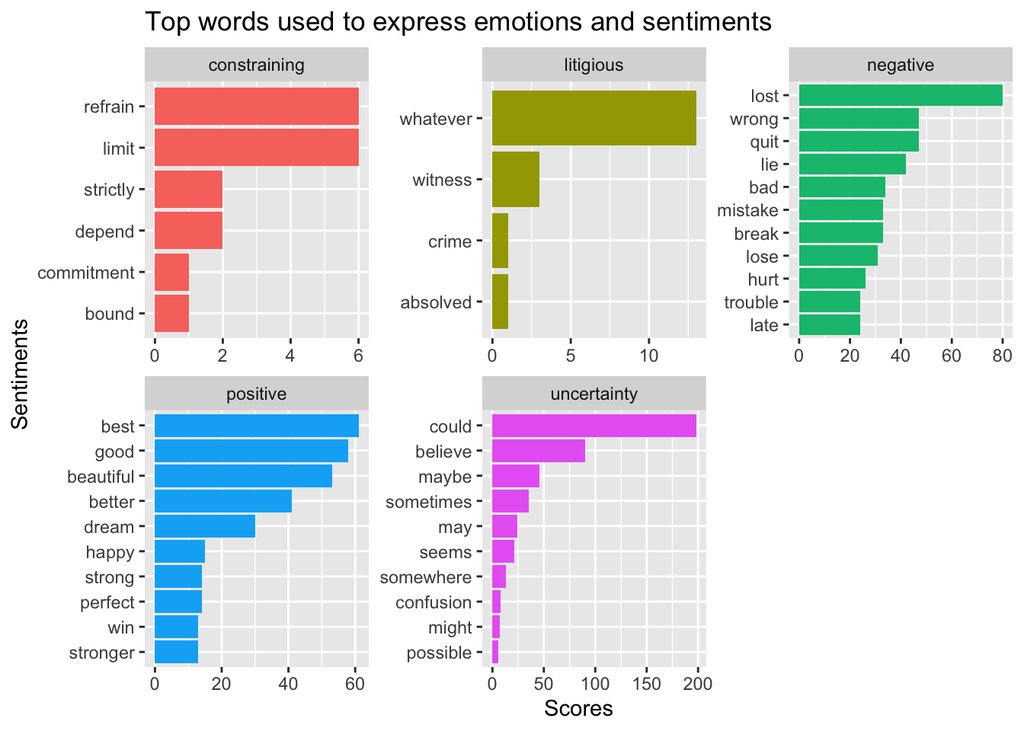

```r
# use loughran lxicon to see top words used to express emotions and sentiments
lyric_sentiment <- lyric_counts %>%
inner_join(get_sentiments("loughran"),by="word")

lyric_sentiment %>%
count(word,sentiment,sort=TRUE) %>%
group_by(sentiment)%>%top_n(n=10) %>%
ungroup() %>%
ggplot(aes(x=reorder(word,n),y=n,fill=sentiment)) +
geom_col(show.legend = FALSE) +
facet_wrap(~sentiment,scales="free") +
xlab("Sentiments") + ylab("Scores")+
ggtitle("Top words used to express emotions and sentiments") +
coord_flip()
```

The visualization shows top word best represent the emotion within each sentiment. For example, `lost` in negative, `best` or `good` in position, `could` in uncertainty.

This brings to the following question – **Which songs are closely associated with different emotions?**

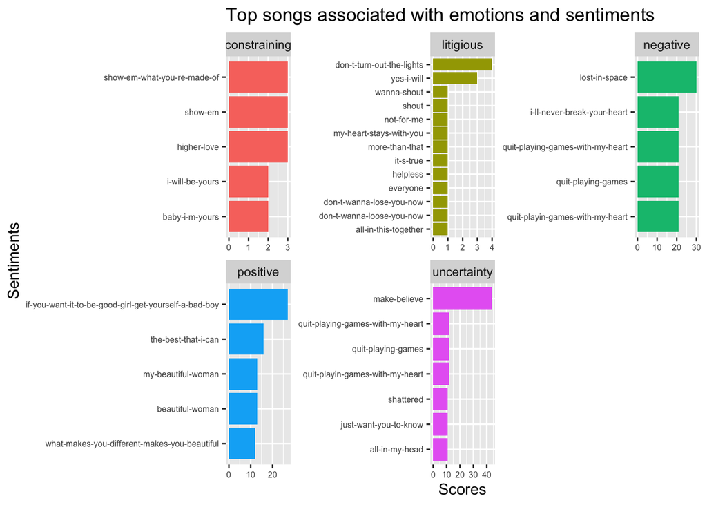

```r
lyric_sentiment %>%
count(song,sentiment,sort=TRUE) %>%
group_by(sentiment) %>%
top_n(n=5) %>%
ggplot(aes(x=reorder(song,n),y=n,fill=sentiment)) +
geom_bar(stat="identity",show.legend = FALSE) +
facet_wrap(~sentiment,scales="free") +
xlab("Sentiments") + ylab("Scores")+
ggtitle("Top songs associated with emotions and sentiments") +
theme (
axis.text.x  = element_text(size=6),
axis.text.y  = element_text(size=6)
) +
coord_flip()
```

We see that the song `make believe` has a lot of uncertainty in comparison to other songs. `quit playing games with my heart` has considerable score for both negative and uncertainty sentiment. We also see that `lost in space` scores high for negative sentiment; most likely because of high frequency words such as `lost`, `wrong`, `quit` and `lie`.

Let’s now move to another sentiment analysis method, bing to create a comparative word cloud of positive and negative sentiment.

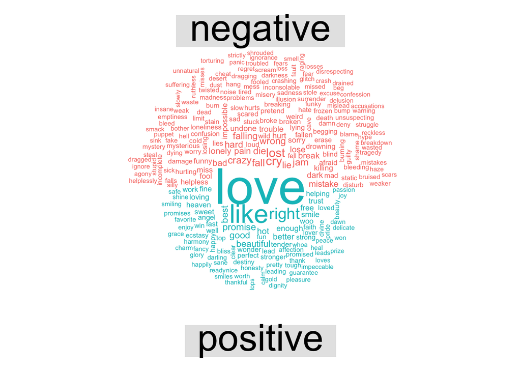

```r
bng <- get_sentiments("bing")

set.seed(1234)

tidy_lyrics %>%
inner_join(get_sentiments("bing")) %>%
count(word, sentiment, sort = TRUE) %>%
acast(word ~ sentiment, value.var = "n", fill = 0) %>%
comparison.cloud(colors = c("#F8766D", "#00BFC4"),
max.words = 250)
```

This brings to the final question – **how have their sentiment and emotions changed over the years?** For this particular answer we will create a visualization called chord diagram to represent.

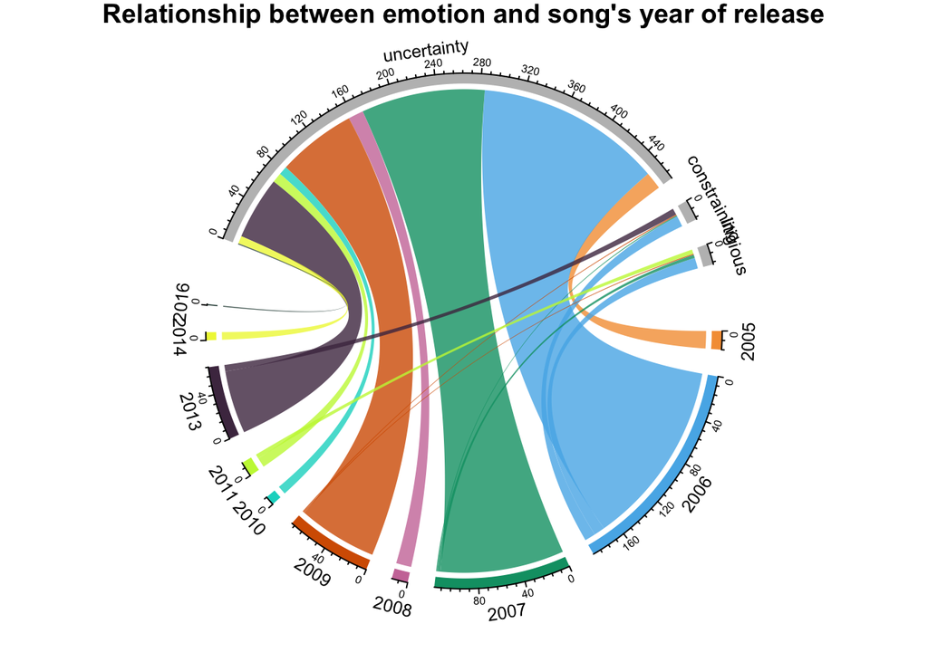

```r
grid.col = c("2005" = "#f59e42", "2006" = "#56B4E9", "2007" = "#009E73", "2008" = "#CC79A7", "2009" = "#D55E00", "2010" = "#00D6C9", "2011" = "#c5f542", "2012" = "#e642f5", "2013" = "#4d334f", "2014" = "#eff542", "2016" = "#334f49", "constraining" = "grey", "litigious" = "grey", "negative" = "grey", "positive" = "grey", "uncertainty" = "grey")

year_emotion <- lyric_sentiment %>%
filter(!sentiment %in% c("positive", "negative")) %>%
count(sentiment, year) %>%
group_by(year, sentiment) %>%
summarise(sentiment_sum = sum(n)) %>%
ungroup()

circos.clear()

#Setting the gap size
circos.par(gap.after = c(rep(6, length(unique(year_emotion[[1]])) - 1), 15,
rep(6, length(unique(year_emotion[[2]])) - 1), 15))

chordDiagram(year_emotion, grid.col = grid.col, transparency = .2)
title("Relationship between emotion and song's year of release")
```

We can see that `uncertainty` has maximum share for the years 2006 and 2007 Overall, `litigious`, `constraining` are the emotions with least score;

For topic modeling on lyrics, we start with sentences and prepare a snipet with a given sentence with the flanking sentences.

```r
# assign new variable
topic_docs <- docs
```

#### Text basic processing & Topic modeling

```r
#remove potentially problematic symbols
topic_docs <-tm_map(topic_docs,content_transformer(tolower))
writeLines(as.character(topic_docs[[sample(1:nrow(lyrics), 1)]]))
```

```
## ill   one
##  guess   lost   met
## still   tears   eyes
##    trust   knew
##    mysteries  lies
##    wild  free
## reachin  like  needed
##  helping hand  make  right
##   holding     night
## ill   one
##  will make   sorrows undone
## ill   light
##   feel like theres nowhere  run
## ill   one
##  hold   make sure  youll  alright
## cause  faith  gone
##   want  take   darkness  light
##    wild  free
## reachin  like  needed
##  helping hand  make  right
##   holding     night
## ill   one
##  will make   sorrows undone
## ill   light
##   feel like theres nowhere  run
## ill   one
##  need  like  need
##  can share  dreams comin true
##  can show   true love means
## just take  hand baby please
## ill   one
## ill   light
##   can run
##  make  alright
## ill   one
## ill   light
##   can run
## ill   one
##  will make   sorrows undone
## ill   light
##   feel like theres nowhere  run
## ill   one
## ill   one
## ill   light
##   can run
##  make  alright
## ill   one
## ill   light
##   can run
##  make   right
## ill   one
##  hold
##  make sure  youll  alright
## ill   one
```

```r
#remove punctuation
topic_docs <- tm_map(topic_docs, removePunctuation)
writeLines(as.character(topic_docs[[sample(1:nrow(lyrics), 1)]]))
```

```
## yeahehheah
##    fire
##  one desire
## believe   say
##  want   way
##    two worlds apart
## cant reach   heart
##   say
##   want   way
## tell
## aint nothin   heartache
## tell
## aint nothin   mistake
## tell
##  never want  hear  say
##  want   way
##    fire
##  one desire
## yes  know   late
##   want   way
## tell
## aint nothin   heartache
## tell
## aint nothin   mistake
## tell
##  never want  hear  say
##  want   way
## now  can see  weve fallen apart
##   way   used   yeah
##  matter  distance
##  want   know
##  deep  inside
##    fire
##  one desire
##
## dont want  hear  say
## aint nothin   heartache
## aint nothin   mistake
## dont want  hear  say
##  never want  hear  say
##  want   way
## tell
## aint nothin   heartache
## tell
## aint nothin   mistake
## tell
##  never want  hear  say
##  want   way
## tell
## aint nothin   heartache
## aint nothin   mistake
## tell
##  never want  hear  say
## never want  hear  say
##  want   way
## cause  want   way
```

```r
#Strip digits
topic_docs <- tm_map(topic_docs, removeNumbers)
writeLines(as.character(topic_docs[[sample(1:nrow(lyrics), 1)]]))
```

```
## show   meaning   lonely
##  many words   broken heart
##  hard  see   crimson love
##  hard  breathe
## walk    maybe
## nights  light  soon become
## wild  free   feel  sun
##  every wish will  done
##  tell
## show   meaning   lonely
##    feeling  need  walk
## tell    cant
## theres something missing   heart
## life goes    never ends
## eyes  stone observe  trends
##  never say forever gaze
## beauty roams   endless love
## theres  control     now
##  every wish will  done
##  tell
## show   meaning   lonely
##    feeling  need  walk
## tell    cant
## theres something missing   heart
## theres nowhere  run    place  go
## surrender  heart body  soul
##  can   youre asking
##  feel  things  never show
## tell   cant
## show   meaning   lonely
##    feeling  need  walk
## tell    cant
## theres something missing   heart
## show   meaning   lonely
##    feeling  need  walk
## tell    cant
## theres something missing   heart
```

```r
#remove stopwords
topic_docs <- tm_map(topic_docs, removeWords, stopwords("english"))
writeLines(as.character(topic_docs[[sample(1:nrow(lyrics), 1)]]))
```

```
## yeah
## yeah yeah
##   looking  something
##   crime scene  youre   deep
##  found  note   number
##  just another clue  leads
##  got  little suspicious
##  got  feeling   aint true
##  shouldve known better
##   buy  lie  sweet disguise
## yeah
##  can fool anyone  ive got eyes  see
##  youre    babe
##   uh uh
## things will never
##   uh uh
## now  know   comin
##   uh uh
## cause   think    way
##  love
## let  tell
##
##  dont want   part   screenplay
## just tell
##   rehearse
## now give   story
##  baby whos  blame maybe
## caught   middle
##  im tired   games  hide  seek
## im getting  feeling
##   time    leave
##  can fool anyone  ive got eyes  see
##  youre    babe
##   uh uh
## things will never
##   uh uh
## now  know   comin
##   uh uh
## cause   think    way
##  love
```

[output cut: 9 more lines]

```
## things will never
##   uh uh
## now  know   comin
##   uh uh
## cause   think    way
##  love
## let  tell
##   uh uh
## things will never
##   uh uh
## now  know   comin
##   uh uh
## cause   think    way
##  love
## let  tell
```

```r
#remove whitespace
topic_docs <- tm_map(topic_docs, stripWhitespace)
writeLines(as.character(topic_docs[[sample(1:nrow(lyrics), 1)]]))
```

```
##  ones mothers lost child ones gypsies left hearts behind strangers sleepin heart take want leave still dark one glamorously lonely song unloved music one last cry prayer tomorrow will help leave past behind song unloved ones bridesmaid never bride ones dreamer locked faith inside widows think the…
```

```r
#Stem document
topic_docs <- tm_map(topic_docs,stemDocument)
writeLines(as.character(topic_docs[[sample(1:nrow(lyrics), 1)]]))
```

```
## away intern away chorus away just wanna take everywher go girl want plane seat right next mine get witchu right show babi give way come girl let fli away intern now dont usual meet circumst your like perfect girl perfect skin im just scare know im gonna leav without girl can call man bridg know a…
```

```r
dtm <- DocumentTermMatrix(topic_docs)

#convert rownames to filenames#convert rownames to filenames
rowTotals <- apply(dtm , 1, sum) #Find the sum of words in each Document
dtm  <- dtm[rowTotals> 0, ]
corpus.list=lyrics[rowTotals>0, ]
```

```r
# Run LDA

#Set parameters for Gibbs sampling
burnin <- 4000
iter <- 2000
thin <- 500
seed <-list(2003,5,63,100001,765)
nstart <- 5
best <- TRUE

#Number of topics
k <- 15

#Run LDA using Gibbs sampling
ldaOut <-LDA(dtm, k, method="Gibbs", control=list(nstart=nstart,
                                                 seed = seed, best=best,
                                                 burnin = burnin, iter = iter,
                                                 thin=thin))

#write out results
#docs to topics
ldaOut.topics <- as.matrix(topics(ldaOut))
table(c(1:k, ldaOut.topics))
```

```
##
##  1  2  3  4  5  6  7  8  9 10 11 12 13 14 15
## 19 16 14 20 14 14 15 23 24 16 11 13 11 18 17
```

```r
write.csv(ldaOut.topics,file=paste("../output/LDAGibbs",k,"DocsToTopics.csv"))

#top 6 terms in each topic
ldaOut.terms <- as.matrix(terms(ldaOut,20))
write.csv(ldaOut.terms,file=paste("../output/LDAGibbs",k,"TopicsToTerms.csv"))

#probabilities associated with each topic assignment
topicProbabilities <- as.data.frame(ldaOut@gamma)
write.csv(topicProbabilities,file=paste("../output/LDAGibbs",k,"TopicProbabilities.csv"))
```

```r
terms.beta=ldaOut@beta
terms.beta=scale(terms.beta)
topics.terms=NULL
for(i in 1:k){
  topics.terms=rbind(topics.terms, ldaOut@terms[order(terms.beta[i,], decreasing = TRUE)[1:7]])
}
topics.terms
```

```
##       [,1]        [,2]        [,3]       [,4]      [,5]        [,6]
##  [1,] "beauti"    "hologram"  "anymor"   "today"   "line"      "weird"
##  [2,] "ooh"       "fade"      "near"     "learn"   "stain"     "disturb"
##  [3,] "rise"      "masquerad" "imma"     "bang"    "ecstasi"   "sunday"
##  [4,] "treat"     "troubl"    "kill"     "along"   "alreadi"   "read"
##  [5,] "bye"       "dreamin"   "isnt"     "leavin"  "shoop"     "cave"
##  [6,] "wish"      "game"      "quit"     "ladi"    "shouldv"   "adrift"
##  [7,] "everybodi" "roll"      "parti"    "rock"    "space"     "babe"
##  [8,] "children"  "rain"      "helpless" "sound"   "everyon"   "land"
##  [9,] "care"      "stuck"     "spanish"  "spend"   "grant"     "despit"
## [10,] "anoth"     "home"      "soldier"  "shatter" "figur"     "shot"
## [11,] "danc"      "song"      "music"    "behind"  "unlov"     "tomorrow"
## [12,] "pda"       "shout"     "funni"    "larger"  "vision"    "public"
## [13,] "nothin"    "mistak"    "heartach" "desir"   "huh"       "fallen"
## [14,] "cri"       "lover"     "prove"    "judg"    "three"     "darl"
```

[output cut: 17 more lines]

```r
print('------------------------------------------------------------------------------------------------------')
```

```
## [1] "------------------------------------------------------------------------------------------------------"
```

```r
ldaOut.terms
```

```
##       Topic 1  Topic 2  Topic 3     Topic 4  Topic 5    Topic 6
##  [1,] "there"  "just"   "one"       "know"   "love"     "babi"
##  [2,] "hey"    "ooh"    "your"      "now"    "know"     "heart"
##  [3,] "tell"   "chorus" "get"       "let"    "think"    "back"
##  [4,] "find"   "ive"    "around"    "cant"   "girl"     "knew"
##  [5,] "take"   "show"   "stay"      "dont"   "somebodi" "wish"
##  [6,] "beauti" "close"  "move"      "gonna"  "bye"      "forev"
##  [7,] "world"  "made"   "babi"      "take"   "say"      "game"
##  [8,] "mean"   "ever"   "caus"      "yeah"   "see"      "said"
##  [9,] "someth" "someon" "girl"      "light"  "wanna"    "time"
## [10,] "thing"  "look"   "kiss"      "wanna"  "yeah"     "true"
## [11,] "feel"   "your"   "hold"      "use"    "goodby"   "quit"
## [12,] "mayb"   "see"    "rise"      "gone"   "anyth"    "tear"
## [13,] "show"   "eye"    "need"      "turn"   "dreamin"  "apart"
## [14,] "run"    "part"   "masquerad" "end"    "realli"   "stop"
```

[output cut: 48 more lines]

[figure not shown]

```r
topics.hash=c("Economy", "Love", "Freedom", "Lifestyle", "Equality", "Belief", "World", "Piece", "Leaders", "Powerful", "Attitude", "Fashion", "Heal", "Fight", "Smart")
corpus.list$ldatopic=as.vector(ldaOut.topics)
corpus.list$ldahash=topics.hash[ldaOut.topics]
colnames(topicProbabilities)=topics.hash
corpus.list.df=cbind(corpus.list, topicProbabilities)
```

#### Conclusion

In this study we performed exploratory analysis and text mining, which includes NLP for sentiment analysis.